# Chapter 5: Dimensionality reduction techniques

Mikko Salonen

21 February 2017

# Chapter 5: Dimensionality reduction techniques

### Preliminaries

Let’s first load the data we produced with the create_human.R script. This data is a collection of gross national income, expected education, life expectancy, education and labor shares between genders, maternal mortality rate, adolescent birth rate, and female political participation rate. In other words this data describes human development in countries.

We can see from the first plot below that GNI, maternal mortality rate, and adolescent birth rate are skewed and right tailed. High kurtosis and left tailed variables are: education ratio, labor ratio, and life expectancy. Expected education is distributed fairly similarly to a normal distribution.

From the second plot we can see that maternal mortality rate and adolescent birth rate are correlated and negatively correlated to high development variables such as: education ratio, GNI, and life expectancy.

```r
human <- read.csv(file = "data/human.csv",row.names = "X")
head(human)
```

```
##               Edu2.FM   Labo.FM Life.Exp Edu.Exp   GNI Mat.Mor Ado.Birth
## Norway      1.0072389 0.8908297     81.6    17.5 64992       4       7.8
## Australia   0.9968288 0.8189415     82.4    20.2 42261       6      12.1
## Switzerland 0.9834369 0.8251001     83.0    15.8 56431       6       1.9
## Denmark     0.9886128 0.8840361     80.2    18.7 44025       5       5.1
## Netherlands 0.9690608 0.8286119     81.6    17.9 45435       6       6.2
## Germany     0.9927835 0.8072289     80.9    16.5 43919       7       3.8
##             Parli.F
## Norway         39.6
## Australia      30.5
## Switzerland    28.5
## Denmark        38.0
## Netherlands    36.9
## Germany        36.9
```

```r
summary(human)
```

```
##     Edu2.FM          Labo.FM          Life.Exp        Edu.Exp
##  Min.   :0.1717   Min.   :0.1857   Min.   :49.00   Min.   : 5.40
##  1st Qu.:0.7264   1st Qu.:0.5984   1st Qu.:66.30   1st Qu.:11.25
##  Median :0.9375   Median :0.7535   Median :74.20   Median :13.50
##  Mean   :0.8529   Mean   :0.7074   Mean   :71.65   Mean   :13.18
##  3rd Qu.:0.9968   3rd Qu.:0.8535   3rd Qu.:77.25   3rd Qu.:15.20
##  Max.   :1.4967   Max.   :1.0380   Max.   :83.50   Max.   :20.20
##       GNI            Mat.Mor         Ado.Birth         Parli.F
##  Min.   :   581   Min.   :   1.0   Min.   :  0.60   Min.   : 0.00
##  1st Qu.:  4198   1st Qu.:  11.5   1st Qu.: 12.65   1st Qu.:12.40
##  Median : 12040   Median :  49.0   Median : 33.60   Median :19.30
##  Mean   : 17628   Mean   : 149.1   Mean   : 47.16   Mean   :20.91
##  3rd Qu.: 24512   3rd Qu.: 190.0   3rd Qu.: 71.95   3rd Qu.:27.95
##  Max.   :123124   Max.   :1100.0   Max.   :204.80   Max.   :57.50
```

```r
dim(human)
```

```
## [1] 155   8
```

```r
str(human)
```

```
## 'data.frame':    155 obs. of  8 variables:
##  $ Edu2.FM  : num  1.007 0.997 0.983 0.989 0.969 ...
##  $ Labo.FM  : num  0.891 0.819 0.825 0.884 0.829 ...
##  $ Life.Exp : num  81.6 82.4 83 80.2 81.6 80.9 80.9 79.1 82 81.8 ...
##  $ Edu.Exp  : num  17.5 20.2 15.8 18.7 17.9 16.5 18.6 16.5 15.9 19.2 ...
##  $ GNI      : int  64992 42261 56431 44025 45435 43919 39568 52947 42155 32689 ...
##  $ Mat.Mor  : int  4 6 6 5 6 7 9 28 11 8 ...
##  $ Ado.Birth: num  7.8 12.1 1.9 5.1 6.2 3.8 8.2 31 14.5 25.3 ...
##  $ Parli.F  : num  39.6 30.5 28.5 38 36.9 36.9 19.9 19.4 28.2 31.4 ...
```

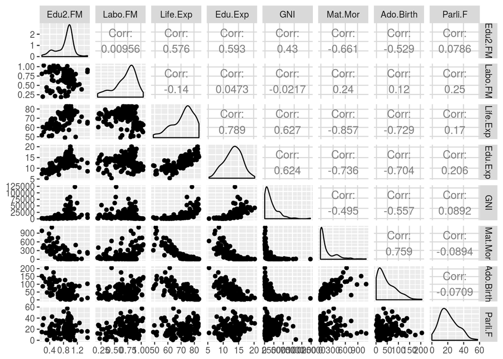

```r
library(GGally)
library(corrplot)
library(tidyr)
library(dplyr)

# visualize the 'human_' variables
ggpairs(human)
```

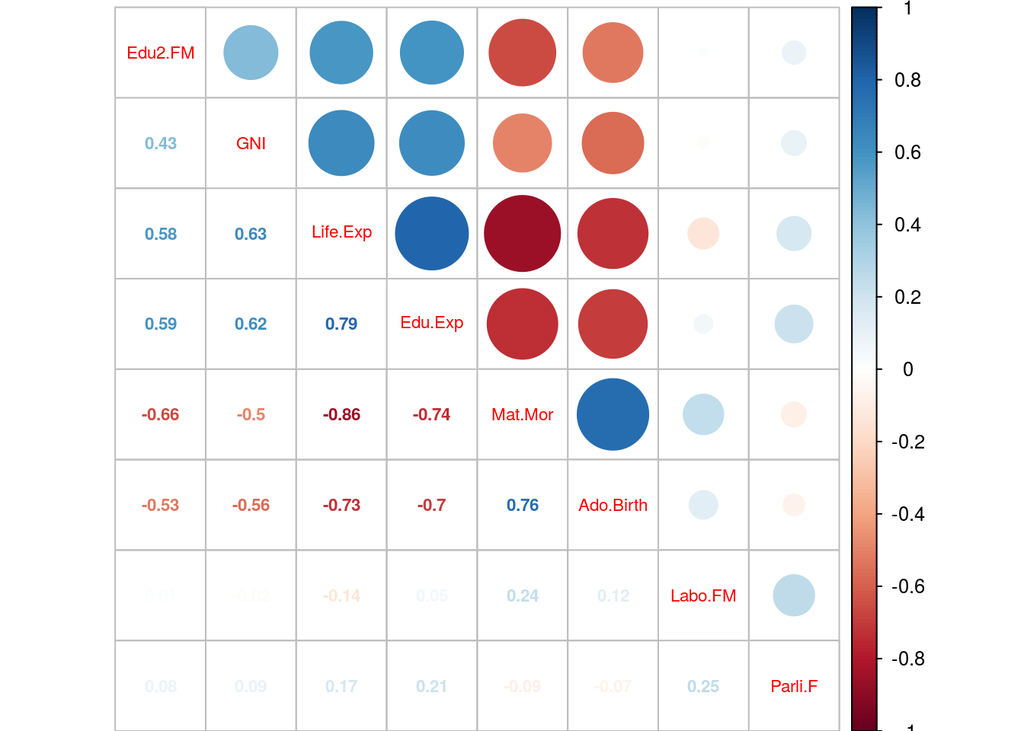

```r
# compute the correlation matrix and visualize it with corrplot
cor(human) %>% round(digits=2) %>% corrplot.mixed(tl.cex = 0.7,number.cex=0.7,order="hclust",addrect=2)
```

### Principal component analysis (PCA)

Let’s perform a PCA on the data. As we can see, without standardization the plot is quite a mess.

```r
# perform principal component analysis (with the SVD method)
pca_human_nstd <- prcomp(human)

# rounded percetanges of variance captured by each PC
pca_pr <- round(1*summary(pca_human_nstd)$importance[2, ], digits = 5)*100

# print out the percentages of variance
pca_pr
```

```
##   PC1   PC2   PC3   PC4   PC5   PC6   PC7   PC8
## 99.99  0.01  0.00  0.00  0.00  0.00  0.00  0.00
```

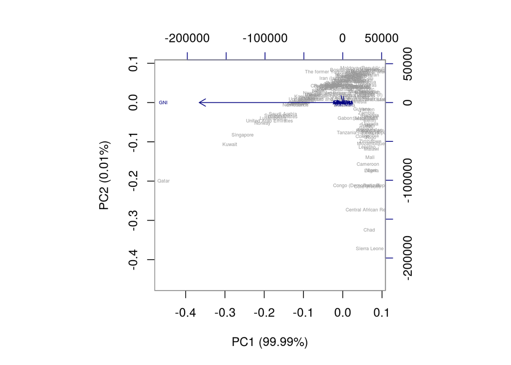

```r
# create object pc_lab to be used as axis labels
pc_lab <- paste0(names(pca_pr), " (", pca_pr, "%)")

# draw a biplot of the principal component representation and the original variables
biplot(pca_human_nstd, choices = 1:2, cex = c(0.4, 0.4), col = c("grey60","navyblue"), xlab = pc_lab[1], ylab = pc_lab[2])
```

Let’s standardize the data now and interprit the results. Without standardisation GNI seems to be orthogonal to all other components, this is because it’s variance is the largest. With standardisation we can see more clearly which components are correlated and which atribute to principal components 1 and 2. Again, the correlations we interpreted before hold. Since female participation and labor ratio point up, this means they are orhogonal, or do not correlate with other variables in the data.

This results seems appropriate, if in a country the child mortality rate is high or the mothers die younger, it is plausible that this has an effect to life expectancy directly but indirectly to expected education rate and therefore to gross national income. One could go as far as to say that the contribution of mothers or more generally females in an important factor in development (PC1). Other part contributing to welfare are the highly correlated components such as GNI, life expectancy, and education. Furhtermore education of females.

```r
# standardize the variables
human_std <- scale(human)

# print out summaries of the standardized variables
summary(human_std)
```

```
##     Edu2.FM           Labo.FM           Life.Exp          Edu.Exp
##  Min.   :-2.8189   Min.   :-2.6247   Min.   :-2.7188   Min.   :-2.7378
##  1st Qu.:-0.5233   1st Qu.:-0.5484   1st Qu.:-0.6425   1st Qu.:-0.6782
##  Median : 0.3503   Median : 0.2316   Median : 0.3056   Median : 0.1140
##  Mean   : 0.0000   Mean   : 0.0000   Mean   : 0.0000   Mean   : 0.0000
##  3rd Qu.: 0.5958   3rd Qu.: 0.7350   3rd Qu.: 0.6717   3rd Qu.: 0.7126
##  Max.   : 2.6646   Max.   : 1.6632   Max.   : 1.4218   Max.   : 2.4730
##       GNI             Mat.Mor          Ado.Birth          Parli.F
##  Min.   :-0.9193   Min.   :-0.6992   Min.   :-1.1325   Min.   :-1.8203
##  1st Qu.:-0.7243   1st Qu.:-0.6496   1st Qu.:-0.8394   1st Qu.:-0.7409
##  Median :-0.3013   Median :-0.4726   Median :-0.3298   Median :-0.1403
##  Mean   : 0.0000   Mean   : 0.0000   Mean   : 0.0000   Mean   : 0.0000
##  3rd Qu.: 0.3712   3rd Qu.: 0.1932   3rd Qu.: 0.6030   3rd Qu.: 0.6127
##  Max.   : 5.6890   Max.   : 4.4899   Max.   : 3.8344   Max.   : 3.1850
```

```r
# perform principal component analysis (with the SVD method)
pca_human <- prcomp(human_std)

# rounded percetanges of variance captured by each PC
pca_pr <- round(1*summary(pca_human)$importance[2, ], digits = 5)*100

# print out the percentages of variance
pca_pr
```

```
##    PC1    PC2    PC3    PC4    PC5    PC6    PC7    PC8
## 53.605 16.237  9.571  7.583  5.477  3.595  2.634  1.298
```

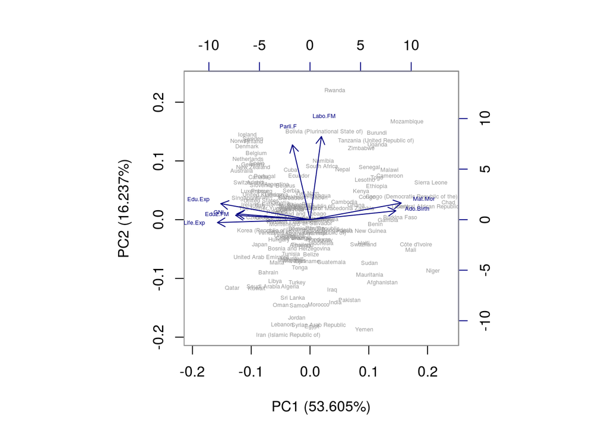

```r
# create object pc_lab to be used as axis labels
pc_lab <- paste0(names(pca_pr), " (", pca_pr, "%)")

# draw a biplot of the principal component representation and the original variables
biplot(pca_human, choices = 1:2, cex = c(0.4, 0.4), col = c("grey60","navyblue"), xlab = pc_lab[1], ylab = pc_lab[2])
```

### Multiple Correspondence Analysis

Next we do a MCA on the tea dataset. There are 300 observations and 36 variables. Let’s cut down on the variables we analyze to a more manageable rate. We include the type of tea (black, green etc.), with or without bonuses (lemon, milk etc.), type of tea package (bag, loose etc.), price (cheap, upscale etc.), with or without sugar,where tea is enjoyed (store, tea shop etc.), and whether or not drinking is done with breakfast.

```r
library(FactoMineR)
library(ggplot2)
library(tidyr)

data(tea)
dim(tea)
```

```
## [1] 300  36
```

```r
str(tea)
```

```
## 'data.frame':    300 obs. of  36 variables:
##  $ breakfast       : Factor w/ 2 levels "breakfast","Not.breakfast": 1 1 2 2 1 2 1 2 1 1 ...
##  $ tea.time        : Factor w/ 2 levels "Not.tea time",..: 1 1 2 1 1 1 2 2 2 1 ...
##  $ evening         : Factor w/ 2 levels "evening","Not.evening": 2 2 1 2 1 2 2 1 2 1 ...
##  $ lunch           : Factor w/ 2 levels "lunch","Not.lunch": 2 2 2 2 2 2 2 2 2 2 ...
##  $ dinner          : Factor w/ 2 levels "dinner","Not.dinner": 2 2 1 1 2 1 2 2 2 2 ...
##  $ always          : Factor w/ 2 levels "always","Not.always": 2 2 2 2 1 2 2 2 2 2 ...
##  $ home            : Factor w/ 2 levels "home","Not.home": 1 1 1 1 1 1 1 1 1 1 ...
##  $ work            : Factor w/ 2 levels "Not.work","work": 1 1 2 1 1 1 1 1 1 1 ...
##  $ tearoom         : Factor w/ 2 levels "Not.tearoom",..: 1 1 1 1 1 1 1 1 1 2 ...
##  $ friends         : Factor w/ 2 levels "friends","Not.friends": 2 2 1 2 2 2 1 2 2 2 ...
##  $ resto           : Factor w/ 2 levels "Not.resto","resto": 1 1 2 1 1 1 1 1 1 1 ...
##  $ pub             : Factor w/ 2 levels "Not.pub","pub": 1 1 1 1 1 1 1 1 1 1 ...
##  $ Tea             : Factor w/ 3 levels "black","Earl Grey",..: 1 1 2 2 2 2 2 1 2 1 ...
##  $ How             : Factor w/ 4 levels "alone","lemon",..: 1 3 1 1 1 1 1 3 3 1 ...
```

[output cut: 22 more lines]

```r
#summary(tea)

# column names to keep in the dataset
# select the columns to keep to create a new dataset
library(dplyr)
tea_time <- select(tea,one_of(c("Tea","How","how","price","sugar","where","breakfast")))


# look at the summaries and structure of the data
#summary(tea_time)
str(tea_time)
```

```
## 'data.frame':    300 obs. of  7 variables:
##  $ Tea      : Factor w/ 3 levels "black","Earl Grey",..: 1 1 2 2 2 2 2 1 2 1 ...
##  $ How      : Factor w/ 4 levels "alone","lemon",..: 1 3 1 1 1 1 1 3 3 1 ...
##  $ how      : Factor w/ 3 levels "tea bag","tea bag+unpackaged",..: 1 1 1 1 1 1 1 1 2 2 ...
##  $ price    : Factor w/ 6 levels "p_branded","p_cheap",..: 4 6 6 6 6 3 6 6 5 5 ...
##  $ sugar    : Factor w/ 2 levels "No.sugar","sugar": 2 1 1 2 1 1 1 1 1 1 ...
##  $ where    : Factor w/ 3 levels "chain store",..: 1 1 1 1 1 1 1 1 2 2 ...
##  $ breakfast: Factor w/ 2 levels "breakfast","Not.breakfast": 1 1 2 2 1 2 1 2 1 1 ...
```

```r
#tea_time
#how, price, where
library(plyr)
```

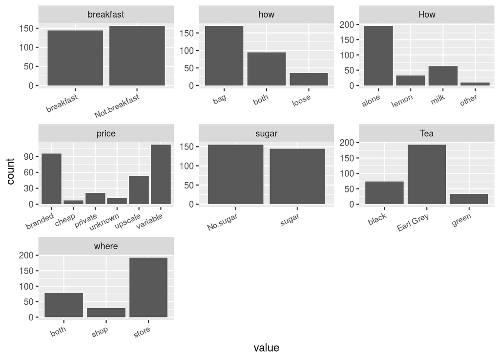

```r
#levels(tea_time$how)
tea_time$how <- mapvalues(tea_time$how, from = c("tea bag", "tea bag+unpackaged", "unpackaged"), to = c("bag", "both", "loose"))
#levels(tea_time$how)

#levels(tea_time$price)
tea_time$price <- mapvalues(tea_time$price, from = c("p_branded","p_cheap","p_private label","p_unknown","p_upscale","p_variable"),to = c("branded", "cheap", "private","unknown","upscale","variable"))
#levels(tea_time$price)

#levels(tea_time$where)
tea_time$where <- mapvalues(tea_time$where, from = c("chain store","chain store+tea shop","tea shop" ),to = c("store", "both", "shop"))
#levels(tea_time$where)

# visualize the dataset
gather(tea_time) %>% ggplot(aes(value)) + facet_wrap("key", scales = "free") + geom_bar() + theme(axis.text.x = element_text(angle = 25, hjust = 1, size = 8))
```

```r
# tea_time is available

# multiple correspondence analysis
mca <- MCA(tea_time, graph = FALSE)

# summary of the model
summary(mca)
```

```
##
## Call:
## MCA(X = tea_time, graph = FALSE)
##
##
## Eigenvalues
##                        Dim.1   Dim.2   Dim.3   Dim.4   Dim.5   Dim.6
## Variance               0.304   0.249   0.188   0.183   0.153   0.148
## % of var.             13.299  10.893   8.218   8.018   6.691   6.483
## Cumulative % of var.  13.299  24.192  32.410  40.428  47.119  53.603
##                        Dim.7   Dim.8   Dim.9  Dim.10  Dim.11  Dim.12
## Variance               0.147   0.142   0.132   0.125   0.115   0.103
## % of var.              6.439   6.197   5.781   5.477   5.026   4.521
## Cumulative % of var.  60.042  66.239  72.020  77.497  82.524  87.045
##                       Dim.13  Dim.14  Dim.15  Dim.16
## Variance               0.095   0.080   0.073   0.048
## % of var.              4.174   3.479   3.210   2.091
## Cumulative % of var.  91.219  94.698  97.909 100.000
##
## Individuals (the 10 first)
##              Dim.1    ctr   cos2    Dim.2    ctr   cos2    Dim.3    ctr
## 1         | -0.471  0.244  0.050 |  0.273  0.100  0.017 |  0.797  1.127
## 2         | -0.210  0.049  0.026 | -0.233  0.073  0.032 |  0.930  1.534
## 3         | -0.281  0.087  0.093 |  0.043  0.002  0.002 | -0.235  0.098
## 4         | -0.396  0.172  0.180 |  0.099  0.013  0.011 | -0.459  0.375
## 5         | -0.305  0.102  0.106 | -0.137  0.025  0.021 |  0.027  0.001
## 6         | -0.469  0.241  0.088 |  0.413  0.228  0.068 | -0.056  0.006
## 7         | -0.305  0.102  0.106 | -0.137  0.025  0.021 |  0.027  0.001
## 8         | -0.187  0.038  0.021 | -0.053  0.004  0.002 |  0.667  0.790
## 9         |  0.545  0.326  0.130 | -0.729  0.711  0.232 |  0.308  0.169
## 10        |  0.792  0.688  0.287 | -0.605  0.490  0.167 |  0.474  0.399
##             cos2
## 1          0.143 |
## 2          0.511 |
## 3          0.065 |
## 4          0.243 |
## 5          0.001 |
## 6          0.001 |
## 7          0.001 |
## 8          0.267 |
```

[output cut: 21 more lines]

```
## milk       -1.797 |   0.892  12.721   0.212   7.956 |
## other      -5.517 |   1.520   5.274   0.071   4.623 |
## how_bag     5.971 |   0.149   0.950   0.029   2.937 |
## how_both  -11.046 |  -0.314   2.354   0.045  -3.671 |
## how_loose   6.662 |   0.119   0.130   0.002   0.763 |
##
## Categorical variables (eta2)
##             Dim.1 Dim.2 Dim.3
## Tea       | 0.091 0.114 0.491 |
## How       | 0.056 0.133 0.338 |
## how       | 0.619 0.463 0.045 |
## price     | 0.611 0.304 0.146 |
## sugar     | 0.049 0.010 0.116 |
## where     | 0.699 0.622 0.021 |
## breakfast | 0.002 0.098 0.158 |
```

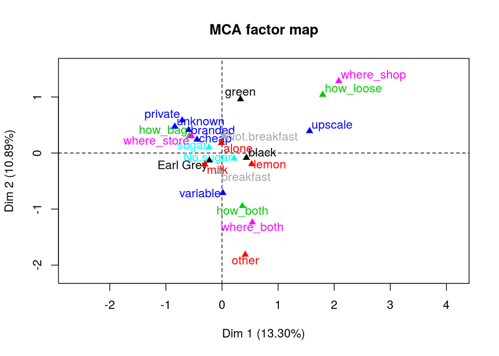

```r
# visualize MCA
plot(mca, invisible=c("ind"), habillage = "quali")
```

First we plot the frequencies of the variables. As we can see, most people use Earl Grey bag tea, drink it alone in a store (home excluded), from all kinds of price ranges, every now and then adding sugar. From the second plot we can see the illustration of the MCA model. We can see that exclusive group ( drinking green upscale loose tea in a tea shop) is more close to each other. The second group noting away from the main group is casual drinkers whom drink in a shop or store a variable price range bag or as loose tea added with a secret ingredient (other, possibly alcohol, I’m thinking about rum toddy here!). I excluded the other MCA graphs as they added little or no further information to the analysis.